# Regresión-optimización de hiperpárametros

Daniel Felipe Pérez Grajales* *Universidad Nacional de Colombia - Sede Medellín* *Efraín Galvis Amaya* *Universidad Nacional de Colombia - Sede Medellín* **Profesor**: *Juan David Ospina Arango* *Universidad Nacional de Colombia - Sede Medellín* *Departamento de Ciencias de la Computación y de la Decisión* *Decisiones bajo incertidumbre (Optimización para aprendizaje de máquina)

11 de junio de 2021

## Predicción del precio de la vivienda en Taiwan

Utilizando el conjunto de datos Real estate valuation data set Data Set lleve a un ejercicio del predicción del precio de la vivienda en Taiwan utilizando los siguientes métodos de predicción:

- Regresión lineal (clásica y elastic net)
- Ensambles de árboles: bosques aleatorios y XGBoost
- Máquinas de soporte vectorial
- Redes neuronales

Es posible dividir el conjunto de datos en entrenamiento y validación o uzar un esquema de validación cruzada.

El conjunto de datos se referncia en la siguiente cita: Citación: Yeh, I. C., & Hsu, T. K. (2018). Building real estate valuation models with comparative approach through case-based reasoning. Applied Soft Computing, 65, 260-271. La definición de las variables es la siguiente:

- $X1$: fecha de la transacción (por ejemplo 2013.250=2013 Marzo, * 2013.500=2013 Junio, etc.)
- $X2$: edad de la casa en años
- $X3$: distancial al MRT (transporte masivo) más cercano en metros
- $X4$: número de tiendas de conveniencia en el vecindario (entero)
- $X5$: latitud (unidad: grados)
- $X6$: longitude (unidad: grados)
- $Y$: precio por unidad de área (10000 Nuevos dólares taiwaneses/ 3.3 $m^2$)

### Data

|  | x1 | x2 | x3 | x4 | x5 | x6 | y |
| --- | --- | --- | --- | --- | --- | --- | --- |
| 1 | 2012.9166667 | 32 | 84.87882 | 10 | 24.98298 | 121.54024 | 37.9 |
| 2 | 2012.9166667 | 19.5 | 306.5947 | 9 | 24.98034 | 121.53951 | 42.2 |
| 3 | 2013.5833333 | 13.3 | 561.9845 | 5 | 24.98746 | 121.54391 | 47.3 |
| 4 | 2013.5 | 13.3 | 561.9845 | 5 | 24.98746 | 121.54391 | 54.8 |
| 5 | 2012.8333333 | 5 | 390.5684 | 5 | 24.97937 | 121.54245 | 43.1 |
| 6 | 2012.6666667 | 7.1 | 2175.03 | 3 | 24.96305 | 121.51254 | 32.1 |

### Descriptivo general

```
## [1] "Identificación de NA'S por variable"
```

```
## x1 x2 x3 x4 x5 x6  y
##  0  0  0  0  0  0  0
```

```
## [1] "Descriptivo1 de variables"
```

```
##        x1             x2               x3                x4
##  Min.   :2013   Min.   : 0.000   Min.   :  23.38   Min.   : 0.000
##  1st Qu.:2013   1st Qu.: 9.025   1st Qu.: 289.32   1st Qu.: 1.000
##  Median :2013   Median :16.100   Median : 492.23   Median : 4.000
##  Mean   :2013   Mean   :17.713   Mean   :1083.89   Mean   : 4.094
##  3rd Qu.:2013   3rd Qu.:28.150   3rd Qu.:1454.28   3rd Qu.: 6.000
##  Max.   :2014   Max.   :43.800   Max.   :6488.02   Max.   :10.000
##        x5              x6              y
##  Min.   :24.93   Min.   :121.5   Min.   :  7.60
##  1st Qu.:24.96   1st Qu.:121.5   1st Qu.: 27.70
##  Median :24.97   Median :121.5   Median : 38.45
##  Mean   :24.97   Mean   :121.5   Mean   : 37.98
##  3rd Qu.:24.98   3rd Qu.:121.5   3rd Qu.: 46.60
##  Max.   :25.01   Max.   :121.6   Max.   :117.50
```

```
## [1] "Descriptivo2 de variables"
```

```
## df
##
##  7  Variables      414  Observations
## --------------------------------------------------------------------------------
## x1
##        n  missing distinct     Info     Mean      Gmd      .05      .10
##      414        0       12    0.991     2013   0.3239     2013     2013
##      .25      .50      .75      .90      .95
##     2013     2013     2013     2014     2014
##
## lowest : 2012.667 2012.750 2012.833 2012.917 2013.000
## highest: 2013.250 2013.333 2013.417 2013.500 2013.583
##
## Value      2012.667 2012.750 2012.833 2012.917 2013.000 2013.083 2013.167
## Frequency        30       27       31       38       28       46       25
## Proportion    0.072    0.065    0.075    0.092    0.068    0.111    0.060
##
## Value      2013.250 2013.333 2013.417 2013.500 2013.583
## Frequency        32       29       58       47       23
## Proportion    0.077    0.070    0.140    0.114    0.056
## --------------------------------------------------------------------------------
## x2
##        n  missing distinct     Info     Mean      Gmd      .05      .10
##      414        0      236        1    17.71    12.93    1.100    3.500
##      .25      .50      .75      .90      .95
##    9.025   16.100   28.150   34.670   37.735
##
## lowest :  0.0  1.0  1.1  1.5  1.7, highest: 40.9 41.3 41.4 42.7 43.8
## --------------------------------------------------------------------------------
## x3
##        n  missing distinct     Info     Mean      Gmd      .05      .10
##      414        0      259        1     1084     1205    90.46   157.61
##      .25      .50      .75      .90      .95
##   289.32   492.23  1454.28  2697.66  4082.01
##
## lowest :   23.38284   49.66105   56.47425   57.58945   82.88643
## highest: 4605.74900 5512.03800 6306.15300 6396.28300 6488.02100
## --------------------------------------------------------------------------------
## x4
##        n  missing distinct     Info     Mean      Gmd      .05      .10
```

[output cut: 21 more lines]

```
##      414        0      232        1    121.5  0.01601    121.5    121.5
##      .25      .50      .75      .90      .95
##    121.5    121.5    121.5    121.5    121.5
##
## lowest : 121.4735 121.4752 121.4788 121.4846 121.4951
## highest: 121.5539 121.5548 121.5596 121.5617 121.5663
## --------------------------------------------------------------------------------
## y
##        n  missing distinct     Info     Mean      Gmd      .05      .10
##      414        0      270        1    37.98    15.13    16.49    21.02
##      .25      .50      .75      .90      .95
##    27.70    38.45    46.60    54.94    59.17
##
## lowest :   7.6  11.2  11.6  12.2  12.8, highest:  71.0  73.6  78.0  78.3 117.5
## --------------------------------------------------------------------------------
```

### Análisis de correlación de variables

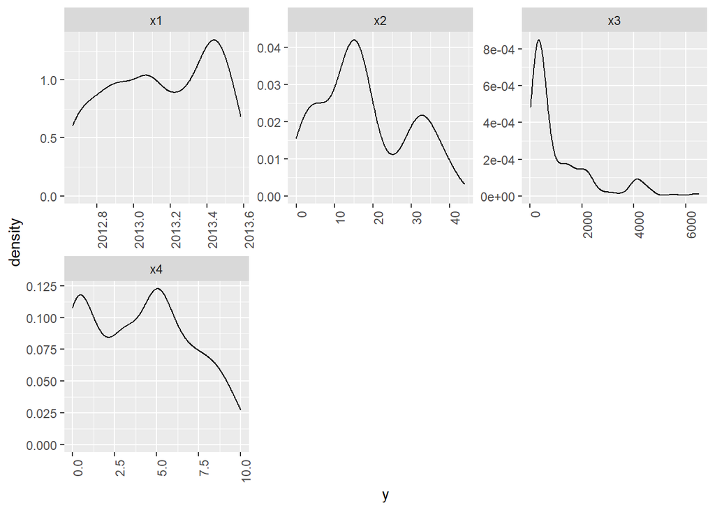

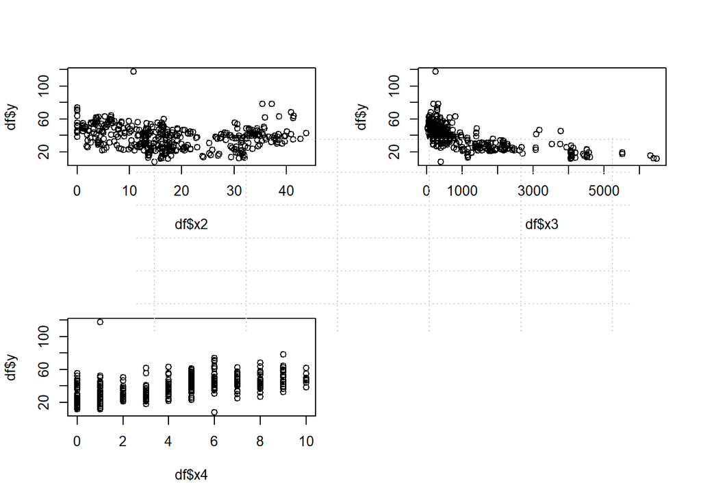

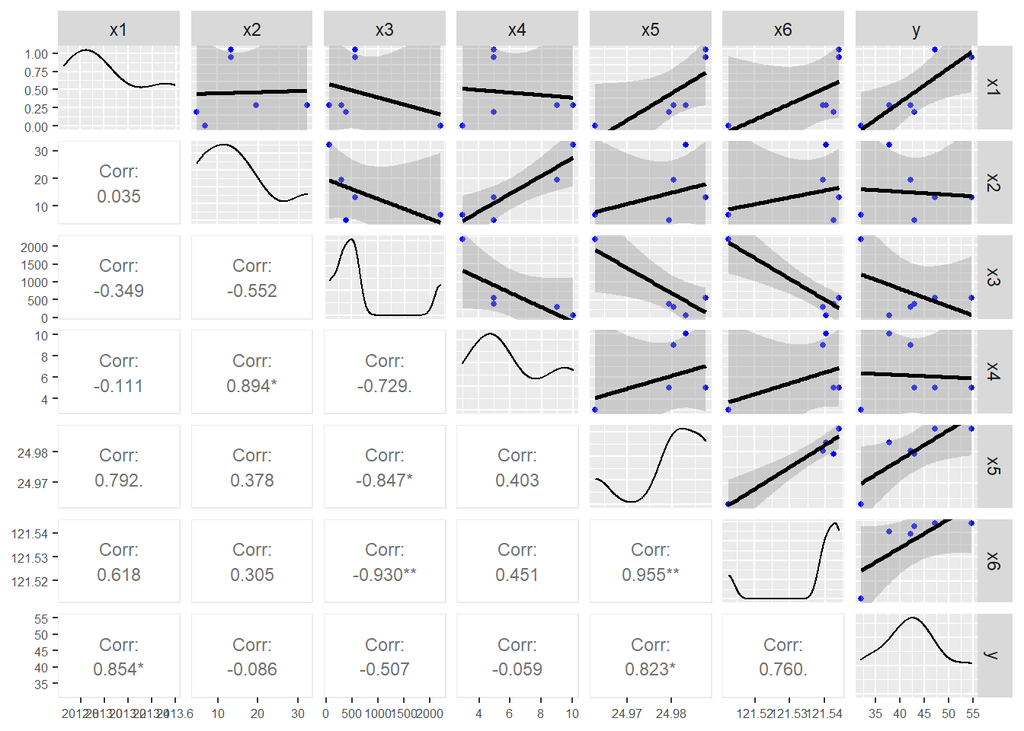

Del análisis preliminar se pueden extraer las siguientes conclusiones:

## Preparación de la información para ser modelada:

- selección de la muestra
- Escalado de datos:

**Advertencia** : si se escala la variable respuesta restándole la media entonces en los modelos lineales no se incluye un intercepto

se eliminan las variables lat y long porque no son faciles de interpretar.

|  | x1 | x2 | x3 | x4 |
| --- | --- | --- | --- | --- |
| 1 | -0.823725007263497 | 1.25411095111314 | -0.791537337603565 | 2.00498155906755 |
| 2 | -0.823725007263497 | 0.156896382725905 | -0.615866476050253 | 1.66548774906593 |
| 3 | 1.54038012439294 | -0.387322043194166 | -0.413514952118236 | 0.307512509059441 |
| 4 | 1.2448670715897 | -0.387322043194166 | -0.413514952118236 | 0.307512509059441 |
| 5 | -1.11923841468201 | -1.11587251660329 | -0.549332079746211 | 0.307512509059441 |
| 6 | -1.71026452028848 | -0.931540469114237 | 0.864540064553073 | -0.371475110943804 |

# creamos nuevas variables

```r
X_scaled$x1_2<-X_scaled$x1^2
X_scaled$x2_2<-X_scaled$x2^2
X_scaled$x3_2<-X_scaled$x3^2
X_scaled$x4_2<-X_scaled$x4^2
datatable(head(X_scaled))
```

|  | x1 | x2 | x3 | x4 | x1_2 | x2_2 | x3_2 | x4_2 |
| --- | --- | --- | --- | --- | --- | --- | --- | --- |
| 1 | -0.823725007263497 | 1.25411095111314 | -0.791537337603565 | 2.00498155906755 | 0.678522887591248 | 1.57279427770191 | 0.62653135682054 | 4.01995105220095 |
| 2 | -0.823725007263497 | 0.156896382725905 | -0.615866476050253 | 1.66548774906593 | 0.678522887591248 | 0.0246164749124735 | 0.379291516322556 | 2.7738494422887 |
| 3 | 1.54038012439294 | -0.387322043194166 | -0.413514952118236 | 0.307512509059441 | 2.3727709276248 | 0.150018365144103 | 0.170994615625347 | 0.0945639432280325 |
| 4 | 1.2448670715897 | -0.387322043194166 | -0.413514952118236 | 0.307512509059441 | 1.54969402592832 | 0.150018365144103 | 0.170994615625347 | 0.0945639432280325 |
| 5 | -1.11923841468201 | -1.11587251660329 | -0.549332079746211 | 0.307512509059441 | 1.2526946288999 | 1.24517147331057 | 0.301765733838297 | 0.0945639432280325 |
| 6 | -1.71026452028848 | -0.931540469114237 | 0.864540064553073 | -0.371475110943804 | 2.92500472935758 | 0.867767645597572 | 0.747429523217432 | 0.137993758050712 |

# Base de entrenamiento y base de validación:

```r
X_tr<-X_scaled[-ix_val,]
X_vl<-X_scaled[ix_val,]
Y_tr<-Y[-ix_val,]
Y_vl<-Y[ix_val,]
```

### Modelo lineal

- Calculemos un modelo lineal:

```
##
## Call:
## lm(formula = y ~ ., data = df_tr)
##
## Residuals:
##     Min      1Q  Median      3Q     Max
## -17.578  -4.408  -0.309   3.477  72.548
##
## Coefficients:
##             Estimate Std. Error t value Pr(>|t|)
## (Intercept)  33.4094     1.0067  33.186  < 2e-16 ***
## x1            2.1350     0.4687   4.555 7.43e-06 ***
## x2           -4.1302     0.5024  -8.221 5.01e-15 ***
## x3          -12.3288     1.0989 -11.219  < 2e-16 ***
## x4            2.2466     0.6555   3.427 0.000689 ***
## x1_2          0.1819     0.5392   0.337 0.736111
## x2_2          2.2387     0.5156   4.342 1.89e-05 ***
## x3_2          2.5533     0.3911   6.529 2.58e-10 ***
## x4_2         -0.1174     0.5026  -0.234 0.815495
## ---
## Signif. codes:  0 '***' 0.001 '**' 0.01 '*' 0.05 '.' 0.1 ' ' 1
##
## Residual standard error: 8.415 on 322 degrees of freedom
## Multiple R-squared:  0.6553, Adjusted R-squared:  0.6467
## F-statistic: 76.51 on 8 and 322 DF,  p-value: < 2.2e-16
```

- Calculo del error cuadrático medio (rmse)

mide cuanto se degrada la predicción del modelo en este caso fue de:

```
## [1] 8.299983
```

precio por unidad de área

- Evaluemos la importancia de una variable por su impacto en la predicción:

```
## [1] 8.548125
```

Aporte de la variable `x1` a la predicción:

```
## [1] -2.989677
```

Este valor me determina la importancia de distorcionar una variable predictora y se identifica cual aporta más al crecimiento del error cuadrático medio,distorción de la predicción

- Calculamos la importancia de las ocho variables:

```
## [1]  -3.0724300  -9.8746673 -17.6612211  -1.7915234   0.1372202  -2.6262241
## [7]  -6.3976581   0.5863169
```

- Graficar importancia de la variables datos perturbados

Estabilizar importancia media

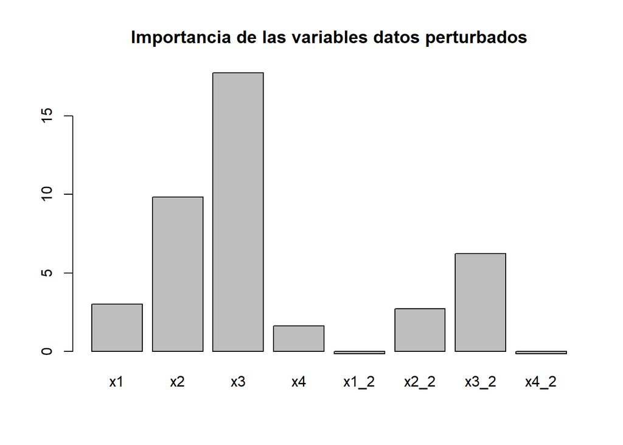

```
## [1]  -3.0144705  -9.8296065 -17.7590190  -1.6213060   0.1443075  -2.7041869
## [7]  -6.2308683   0.1618022
```

- Importancia por coeficientes

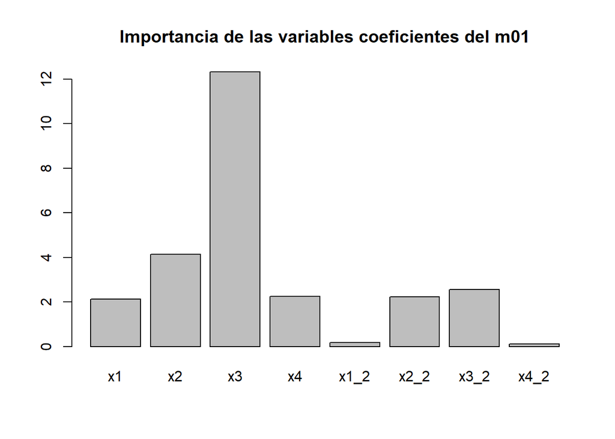

- importancia por estadístico t

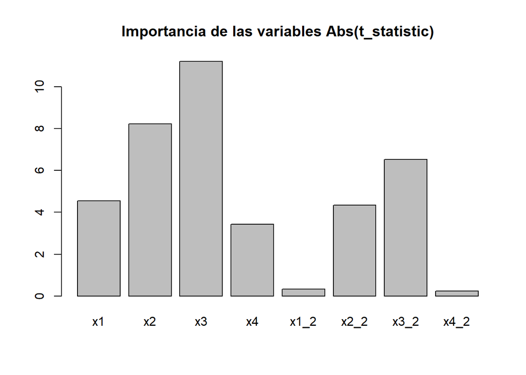

La variable más importante para la predicción del precio por unidad de área es $x3$: distancial al MRT (transporte masivo) más cercano en metros

### Regresión lineal (elastic net)

- Definición de los parámetros de optimización:

```r
hiperparametros <- expand.grid(
  alpha = (1:100)/100,
  lambda = 10^(-5:2)
)
control_optimizacion <- caret::trainControl(method = "LGOCV", number = 10,p=0.2)
```

- optimización Modelo:

```r
m02 <- train(
  y~-1+.,data = df_tr,
  method = "glmnet",
  trControl = control_optimizacion,
  tuneGrid = hiperparametros
)
```

- Mejor modelo elastic net con el RMSE más bajo

|  | alpha | lambda | RMSE | Rsquared | MAE | RMSESD | RsquaredSD | MAESD |
| --- | --- | --- | --- | --- | --- | --- | --- | --- |
| 14 | 0.02 | 1 | 9.15709186946298 | 0.59622563247381 | 6.28518109637957 | 0.717302896610777 | 0.0503072383591911 | 0.509053633578469 |
| 6 | 0.01 | 1 | 9.1570984160108 | 0.596187788241405 | 6.28422744923835 | 0.717636079792451 | 0.0504378200551588 | 0.511111656549688 |
| 22 | 0.03 | 1 | 9.15724491222271 | 0.596251522765695 | 6.2862392260623 | 0.717068505336077 | 0.0501881097955061 | 0.507044103872698 |
| 30 | 0.04 | 1 | 9.15755631769605 | 0.596265229446793 | 6.28752316096219 | 0.716798977938873 | 0.0500665725065228 | 0.504991388176955 |
| 38 | 0.05 | 1 | 9.15797335581533 | 0.59627107201657 | 6.28898819124475 | 0.716579995547792 | 0.0499487355878282 | 0.502897188344192 |
| 46 | 0.06 | 1 | 9.15851348223389 | 0.59626827934742 | 6.29053175546451 | 0.716370464301368 | 0.0498326009543189 | 0.500799892525394 |

Mejor rmse óptimizado del modelo elastic net:

```
## [1] 9.157092
```

### Optimización de árboles CART

Optimizacion 1 modelo 1

```r
# M1 #####
set.seed(123)
model <- train(
  y ~., data = train, method = "rpart",
  trControl = trainControl("cv", number = 20),
  tuneLength = 10
)
#plot(model)
print("mejores parametros")
```

```
## [1] "mejores parametros"
```

```r
paste(print(model$bestTune))
```

```
##            cp
## 2 0.006874159
```

```
## [1] "0.00687415868359284"
```

rmse modelo 1 arból optimizado

```r
tree <- rpart::rpart(y ~ .,
                     data = train,
                     method="anova",
                     cp = as.numeric(model$bestTune))
pred <- predict(tree, X_vl)
M1_arb_Op_rmse <- RMSE(pred, Y_vl$y)
M1_arb_Op_rmse
```

```
## [1] 9.005772
```

Planteamos una segunda alternativa de optimizacion para encontrar el mejor modelo, que contiene un grid con de 4235 combinaciones de parametros maxdepth y mincriterion.

```r
# M2####
set.seed(123)
model <- train(
  y ~., data = train, method = "ctree2",
  trControl = trainControl("cv", number = 10),
  tuneGrid = expand.grid(maxdepth = c(1:35),
                         mincriterion = seq(0.85, 0.97, 0.001) )
)

print("mejores parametros")
```

```
## [1] "mejores parametros"
```

```r
paste(print(model$bestTune))
```

```
##     maxdepth mincriterion
## 303        3         0.91
```

```
## [1] "3"    "0.91"
```

rmse modelo 2 arból optimizado

```
## [1] 8.831018
```

Ahora, planteamos una segunda alternativa de optimizacion para encontrar el mejor modelo, que contiene un grid con de 2001 con el parámetro cp

```r
# M3 ####
numFolds = trainControl( method = "cv", number = 10 )
cpGrid = expand.grid( .cp = seq(0.01,0.03,0.00001))

mod1 <- train(y ~ ., data = train,
              method = "rpart",
              trControl = numFolds,
              tuneGrid = cpGrid )

print("mejores parametros")
```

```
## [1] "mejores parametros"
```

```r
paste(print(mod1$bestTune))
```

```
##        cp
## 7 0.01006
```

```
## [1] "0.01006"
```

rmse modelo 3 arból optimizado

```
## [1] 9.005772
```

Finalmente se recopilan los distintas salidas de RMSE de los 3 modelos optimizados

```
##    Modelo1  Modelo2  Modelo3
## 1 9.005772 8.831018 9.005772
```

Se puede concluir de lo anterior que el mejor modelo, luego de las tres metodologías implementadas, fue la optimización del modelo 2, ya que da un RMSE de

```
## [1] 8.831018
```

### Ensambles de árboles

bosques aleatorios

```
##
## Call:
##  randomForest(formula = y ~ ., data = df_tr, importance = TRUE)
##                Type of random forest: regression
##                      Number of trees: 500
## No. of variables tried at each split: 2
##
##           Mean of squared residuals: 59.97074
##                     % Var explained: 69.99
```

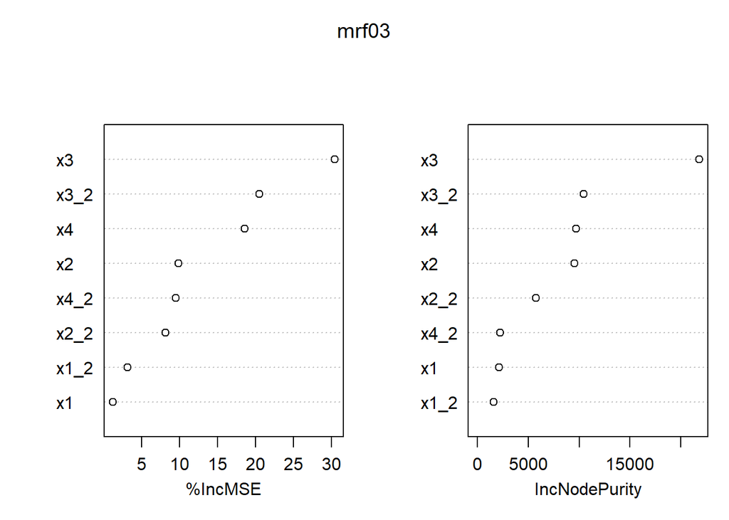

se concluye que la variable mas importante es $X3$:distancia al MRT (transporte masivo) más cercano en metros, seguido de la misma variable elevada al cuadrado,en tercer lugar la variable $X4$: número de tiendas de conveniencia en el vecindario (entero)

El rmse del Random Forest mide cuanto se degrada la predicción del modelo en este caso fue de:

```
## [1] 7.744078
```

precio por unidad de área

### XGBoost

El rmse del XGboost mide cuanto se degrada la predicción del modelo en este caso fue de:

```
## [1] 7.200536
```

precio por unidad de área

- Definición de los parámetros de optimización:

```r
gbmGrid2 <-  expand.grid(interaction.depth = c(1, 5, 9),
                         n.trees = (1:30)*50,
                         shrinkage = c(0.0001, 0.001, 0.01, 0.1, 0.2, 0.3),
                         n.minobsinnode = 20)

fitControl <- trainControl(## 10-fold CV
  method = "repeatedcv",
  number = 10,
  repeats = 10)
```

- optimización Modelo XGboost:

```r
set.seed(825)
gbmFit2 <- train(y ~ ., data = df_tr,
                 method = "gbm",
                 trControl = fitControl,
                 verbose = FALSE,
                 tuneGrid = gbmGrid2)
```

- hiperparámetros mejor modelo XGboost con el RMSE más bajo

|  | shrinkage | interaction.depth | n.minobsinnode | n.trees | RMSE | Rsquared | MAE | RMSESD | RsquaredSD | MAESD |
| --- | --- | --- | --- | --- | --- | --- | --- | --- | --- | --- |
| 222 | 0.01 | 5 | 20 | 600 | 7.43678346920549 | 0.730691487484113 | 5.10322665698718 | 2.74097519122578 | 0.130745196671001 | 1.04144879840937 |
| 223 | 0.01 | 5 | 20 | 650 | 7.43777229619287 | 0.730571833714451 | 5.10893348903354 | 2.75440386137008 | 0.131769967161247 | 1.04631255873444 |
| 221 | 0.01 | 5 | 20 | 550 | 7.43790555688464 | 0.730606852487267 | 5.10257321237488 | 2.72297472620809 | 0.129507382456854 | 1.03785363578215 |
| 220 | 0.01 | 5 | 20 | 500 | 7.43945712398408 | 0.730431038553231 | 5.10272214565511 | 2.70436146734167 | 0.128103854423315 | 1.03106130894388 |
| 254 | 0.01 | 9 | 20 | 700 | 7.44187030664582 | 0.730462444411884 | 5.10910218690452 | 2.75654185695165 | 0.13189257918841 | 1.03753651919389 |
| 251 | 0.01 | 9 | 20 | 550 | 7.44208386485928 | 0.730394069724854 | 5.10164026619856 | 2.71670839431256 | 0.128809080772363 | 1.03149766845388 |

Mejor rmse óptimizado del modelo XGboost es:

```
## [1] 7.436783
```

### Máquinas de soporte vectorial

```r
m_svm <- svm(y ~ ., data = df_tr,type = 'eps-regression')
y_svm_pred <- predict(m_svm)
error_svm <- Y_tr$y - y_svm_pred
rmse_svm <- sqrt(mean(error_svm^2))
#(RMSEsvm=rmse(pred_valid_svm,test$y))
```

el modelo de máquinas de soporte vectorial tiene error cuadrático medio de:

```
## [1] 7.779266
```

precio por unidad de área

### Redes neuronales

El rmse del Red neuronal que mide cuanto se degrada la predicción del modelo en este caso fue de:

```
## [1] 5.604826
```

precio por unidad de área

## Preguntas adicionales

*1. ¿Qué variables tienen el mayor impacto en el precio de la vivienda?*

Las variables $X3$:distancia al MRT (transporte masivo) más cercano en metros en el análisis de correlación se evidencia una dependecia lineal medianamente al precio por unidad de área de la vivienda en Taiwan.en los modelos regresión lineal se identificó como la variable más importante, al igual que en el modelo de bosque aleatorios.

*¿Cómo aporta cada modelo al conocimiento de este impacto?*

En la identificación de la importancia de las variables al modelo, el impacto se nota en el error cuadratico medio(RMSE) al hacer distorsión en las variables más importantes como lo fue $x3$ era significativo el aporte al error de predicción del modelo.

*2. ¿Cuál es el mejor modelo entre los usados para resolver este problema?*

El mejor modelo con un RMSE de:

```
## [1] 5.604826
```

precio por unidad de área de la vivienda en Taiwan y fue la red neuronal con el menor error cuadrático medio.

*¿Qué criterios se pueden utilizar para responder a esta pregunta?*

para este caso por los modelos de: Regresión lineal (clásica y elastic net),Ensambles de árboles: bosques aleatorios y XGBoost,Máquinas de soporte vectorial, Redes neuronales, se busca una medida del error de ajuste de la predicción que se pueda calcular en todos los modelos como lo es el error cuadrático medio(RMSE) y se pueda comparar entre todos.El de menor RMSE será el que tiene menor error al predecir el precio por unidad de área de la vivienda en Taiwan.

De acuerdo a los siguientes resultados:

```
##   Modelo1_rmse_regresion Modelo2_rmse_elastic_net_opt Modelo3_rmse_arbol_opt
## 1               8.299983                     9.157092               8.831018
##   Modelo4_rmse_randomForest Modelo5_rmse_XGBoost_opt Modelo6_rmse_svm
## 1                  7.744078                 7.436783         7.779266
##   Modelo7_rmse_nnet
## 1          5.604826
```